# Practical Machine Learning: Course Project (Prediction Assignment Writeup)

Hedayat Alibeiki

## Background

It is now possible to collect a large amount of data about personal activity relatively inexpensively with quantified Self devices . The goal of this project is to utilize a sample data from accelerometers on the belt, forearm, arm, and dumbell of 6 participants and then predict the manner in which they did the exercise.

## Analysis

In this analysis we build a machine learning model from the sample data with the aim to accurately predict the manner in which the exercises were done. This is a classification problem with discrete categories: the ‘classe’ varaible in traning data.

### Loading Data and Preprocess

The first step in the project is to download the data to the directory. There are 2 data sets, the training data set and the testing data set. We do predict testing data using the final model that is based on training data. When the data is loaded into dataframes, it is necessary to locate strings containing ‘#DIV/0!’, which is a common error code for division by zero. These error codes are loaded into the data frame as NA fields. The follwoing code chunk will perform these tasks.

```r
library(caret, quietly=TRUE)
adrs_train <- 'https://d396qusza40orc.cloudfront.net/predmachlearn/pml-training.csv'
adrs_test <- 'https://d396qusza40orc.cloudfront.net/predmachlearn/pml-testing.csv'
#download.file(url = adrs_train, destfile = 'data_train.csv')
#download.file(url = adrs_test, destfile = 'data_test.csv')
pml_train <- read.csv(file = 'data_train.csv',
                      na.strings = c('NA','#DIV/0!',''))
pml_test <- read.csv(file = 'data_test.csv',
                     na.strings = c('NA','#DIV/0!',''))
```

The exploratory analysis shows that the first 7 dimensional fields of the data may not be relevant to the prediction model. The balance of the fields are numeric according to the data documentation available online. We do this through a “for loop” for all other columns except for “classe”, which is the categorical variable that the prediction model is to classify it.

```r
for(i in c(8:ncol(pml_train)-1)) {
  pml_train[,i] = as.numeric(as.character(pml_train[,i]))
  pml_test[,i] = as.numeric(as.character(pml_test[,i]))
}
```

Further analysis reveals that of the many variables, several are very irrelevant and thus may not be as useful for building a classification model. The following code removes the columns with null values, and also removes the inital seven columns of dimensional data. From now on, we use this vector of column names as the main index into the training data, cross-validation data, and the testing data when interacting with a model.

```r
feature_index <- colnames(pml_train)
feature_index <- colnames(pml_train[colSums(is.na(pml_train)) == 0])
feature_index <- feature_index[-c(1:7)]
```

### Divide Data to Testing and Cross-Validation sets

```r
set.seed(800)
index_train <- createDataPartition(y=pml_train$classe, p=0.80, list=FALSE)
data_train <- pml_train[index_train,feature_index]
data_xval <- pml_train[-index_train,feature_index]
dim(data_train); dim(data_xval)
```

```
## [1] 15699    53
```

```
## [1] 3923   53
```

### Closer Look at Frequency of Each Class (distribution examination)

Before choosing a model to fit the data, it is useful to have an idea that what is the total expected proportion of each classification variable outcome in the prediction. This wil help us to optimize models for Specificity, Sensitivity, and Positive/Negative Predictive Value.

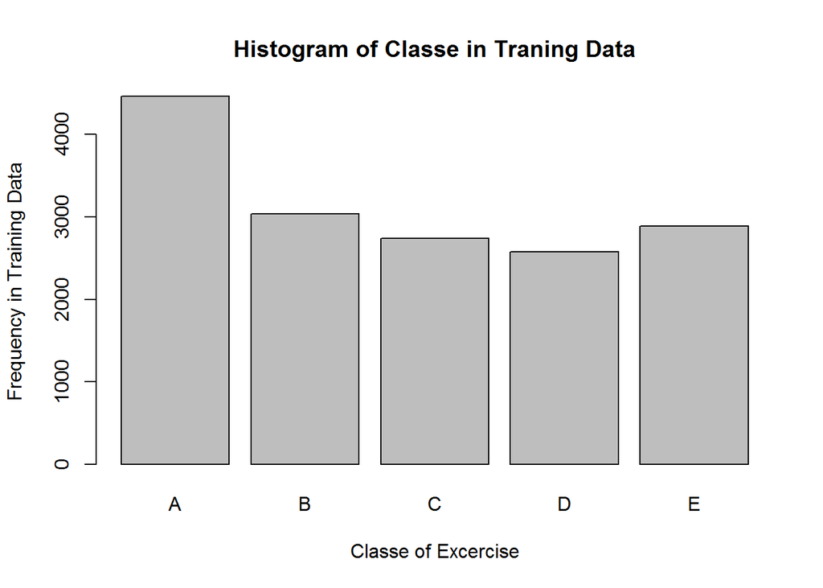

```r
plot(data_train$classe, main="Histogram of Classe in Traning Data", xlab="Classe of Excercise", ylab="Frequency in Training Data")
```

### Training Model and Cross Validating

From the previous analyses, we choose a Random Forest model to fit the data and predict “classe”.

```r
mod_rf <- train(classe ~ .,
                data = data_train,
                method = 'rf',
                trControl = trainControl(method = "cv",
                                         number = 4,
                                         allowParallel = TRUE,
                                         verboseIter = TRUE))
pred_rf <- predict(mod_rf,data_xval)
cm_rf <- confusionMatrix(pred_rf,data_xval$classe)
```

#### Predictions on Cross Validation Data

```r
cm_rf
```

```
## Confusion Matrix and Statistics
##
##           Reference
## Prediction    A    B    C    D    E
##          A 1116    5    0    0    0
##          B    0  753    8    0    0
##          C    0    1  675    9    0
##          D    0    0    1  632    0
##          E    0    0    0    2  721
##
## Overall Statistics
##
##                Accuracy : 0.9934
##                  95% CI : (0.9903, 0.9957)
##     No Information Rate : 0.2845
##     P-Value [Acc > NIR] : < 2.2e-16
##
##                   Kappa : 0.9916
##  Mcnemar's Test P-Value : NA
##
## Statistics by Class:
##
##                      Class: A Class: B Class: C Class: D Class: E
## Sensitivity            1.0000   0.9921   0.9868   0.9829   1.0000
## Specificity            0.9982   0.9975   0.9969   0.9997   0.9994
## Pos Pred Value         0.9955   0.9895   0.9854   0.9984   0.9972
## Neg Pred Value         1.0000   0.9981   0.9972   0.9967   1.0000
## Prevalence             0.2845   0.1935   0.1744   0.1639   0.1838
## Detection Rate         0.2845   0.1919   0.1721   0.1611   0.1838
## Detection Prevalence   0.2858   0.1940   0.1746   0.1614   0.1843
## Balanced Accuracy      0.9991   0.9948   0.9919   0.9913   0.9997
```

## Applying Trained Model to the Test Set

For the test results, there are 20 samples asked to be classified. We first make sure that the column names are consistent between the test and training data by renaming the last column in the testing set for compatability purpose. Once the predictions are made from the chosen Random Forest model, the prediction vector is shown.

```r
final_col <- length(colnames(pml_test[]))
colnames(pml_test)[final_col] <- 'classe'
test_rf <- predict(mod_rf,pml_test[,feature_index])
test_rf
```

```
##  [1] B A B A A E D B A A B C B A E E A B B B
## Levels: A B C D E
```